# Running PK models with nlmixr

2019-08-28

nlmixr

# Running PK models with nlmixr

nlmixr uses a unified interface for specifying and running models. Let’s start with a very simple PK example, using the single-dose theophylline dataset generously provided by Dr. Robert A. Upton of the University of California, San Francisco:

```r
## Load libraries
library(ggplot2)
library(nlmixr)
str(theo_sd)
```

```
#> 'data.frame':    144 obs. of  7 variables:
#>  $ ID  : int  1 1 1 1 1 1 1 1 1 1 ...
#>  $ TIME: num  0 0 0.25 0.57 1.12 2.02 3.82 5.1 7.03 9.05 ...
#>  $ DV  : num  0 0.74 2.84 6.57 10.5 9.66 8.58 8.36 7.47 6.89 ...
#>  $ AMT : num  320 0 0 0 0 ...
#>  $ EVID: int  101 0 0 0 0 0 0 0 0 0 ...
#>  $ CMT : int  1 2 2 2 2 2 2 2 2 2 ...
#>  $ WT  : num  79.6 79.6 79.6 79.6 79.6 79.6 79.6 79.6 79.6 79.6 ...
```

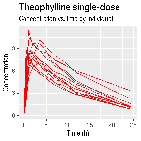

```r
ggplot(theo_sd, aes(TIME, DV)) + geom_line(aes(group=ID), col="red") + scale_x_continuous("Time (h)") + scale_y_continuous("Concentration") + labs(title="Theophylline single-dose", subtitle="Concentration vs. time by individual")
```

We can try fitting a simple one-compartment PK model to this small dataset. We write the model as follows:

```r
one.cmt <- function() {
    ini({
        ## You may label each parameter with a comment
        tka <- 0.45 # Log Ka
        tcl <- 1 # Log Cl
        ## This works with interactive models
        ## You may also label the preceding line with label("label text")
        tv <- 3.45; label("log V")
        ## the label("Label name") works with all models
        eta.ka ~ 0.6
        eta.cl ~ 0.3
        eta.v ~ 0.1
        add.sd <- 0.7
    })
    model({
        ka <- exp(tka + eta.ka)
        cl <- exp(tcl + eta.cl)
        v <- exp(tv + eta.v)
        linCmt() ~ add(add.sd)
    })
}
```

Now setup the cache dir for running the vignette fast (a CRAN requirement)

```r
dir <- system.file(package="nlmixr");
```

We can now run the model…

[output not shown]

```r
fit <- readRDS(file.path(dir,"fit.rds"))
print(fit)
```

[output not shown]

We can alternatively express the same model by ordinary differential equations (ODEs):

```r
one.compartment <- function() {
    ini({
        tka <- 0.45 # Log Ka
        tcl <- 1 # Log Cl
        tv <- 3.45    # Log V
        eta.ka ~ 0.6
        eta.cl ~ 0.3
        eta.v ~ 0.1
        add.sd <- 0.7
    })
    model({
        ka <- exp(tka + eta.ka)
        cl <- exp(tcl + eta.cl)
        v <- exp(tv + eta.v)
        d/dt(depot) = -ka * depot
        d/dt(center) = ka * depot - cl / v * center
        cp = center / v
        cp ~ add(add.sd)
    })
}
```

We can try the Stochastic Approximation EM (SAEM) method to this model:

```
fit2 <- nlmixr(one.compartment, theo_sd, est="saem")
saveRDS(fit2, file.path(dir,"fit2.rds")); # This saves the rds file for running quickly
```

```r
fit2 <- readRDS(file.path(dir,"fit2.rds")); # This saves the rds file for running quickly
print(fit2)
```

```
#> ── nlmixr SAEM(ODE); OBJF not calculated fit ──────────────────────────────
#>  Gaussian/Laplacian Likelihoods: AIC() or $objf etc.
#>  FOCEi CWRES & Likelihoods: addCwres()
#>
#> ── Time (sec; $time): ─────────────────────────────────────────────────────
#>           saem    setup table covariance    other
#> elapsed 17.675 2.481686  0.06      0.018 2.235314
#>
#> ── Population Parameters ($parFixed or $parFixedDf): ──────────────────────
#>        Parameter  Est.     SE %RSE Back-transformed(95%CI) BSV(CV%)
#> tka       Log Ka 0.451  0.196 43.5       1.57 (1.07, 2.31)     71.9
#> tcl       Log Cl  1.02 0.0836 8.22       2.77 (2.35, 3.26)     27.0
#> tv         Log V  3.45 0.0469 1.36       31.5 (28.7, 34.5)     14.0
#> add.sd           0.692                               0.692
#>        Shrink(SD)%
#> tka        0.411%
#> tcl         3.36%
#> tv          10.0%
#> add.sd
#>
#>   Covariance Type ($covMethod): linFim
#>   No correlations in between subject variability (BSV) matrix
#>   Full BSV covariance ($omega) or correlation ($omegaR; diagonals=SDs)
#>   Distribution stats (mean/skewness/kurtosis/p-value) available in $shrink
#>
#> ── Fit Data (object is a modified tibble): ────────────────────────────────
#> # A tibble: 132 x 18
#>   ID     TIME    DV  EVID  PRED    RES IPRED   IRES  IWRES eta.ka eta.cl
#>   <fct> <dbl> <dbl> <int> <dbl>  <dbl> <dbl>  <dbl>  <dbl>  <dbl>  <dbl>
#> 1 1     0      0.74     0  0     0.74   0     0.74   1.07   0.105 -0.487
#> 2 1     0.25   2.84     0  3.26 -0.423  3.86 -1.02  -1.48   0.105 -0.487
#> 3 1     0.570  6.57     0  5.84  0.725  6.81 -0.235 -0.340  0.105 -0.487
#> # … with 129 more rows, and 7 more variables: eta.v <dbl>, ka <dbl>,
#> #   cl <dbl>, v <dbl>, cp <dbl>, depot <dbl>, center <dbl>
```

And if we wanted to, we could even apply the First-Order Conditional Estimation (FOCEi) method to this model:

```
fitF <- nlmixr(one.compartment, theo_sd, est="focei")
saveRDS(fitF, file.path(dir,"fitF.rds")); # This saves the rds file for running quickly
```

```r
fitF <- readRDS(file.path(dir,"fitF.rds")); # This saves the rds file for running quickly
print(fitF)
```

```
#> ── nlmixr FOCEi (outer: nlminb) fit ───────────────────────────────────────
#>           OBJF      AIC      BIC Log-likelihood Condition Number
#> FOCEi 116.8079 373.4076 393.5872      -179.7038         24.76031
#>
#> ── Time (sec; $time): ─────────────────────────────────────────────────────
#>           setup optimize covariance table    other
#> elapsed 6.01781 0.316758   0.316759  0.01 1.409673
#>
#> ── Population Parameters ($parFixed or $parFixedDf): ──────────────────────
#>        Parameter  Est.     SE %RSE Back-transformed(95%CI) BSV(CV%)
#> tka       Log Ka 0.465   0.21 45.2        1.59 (1.05, 2.4)     69.7
#> tcl       Log Cl  1.01 0.0847 8.37       2.75 (2.33, 3.25)     26.4
#> tv         Log V  3.46  0.116 3.35       31.8 (25.4, 39.9)     13.8
#> add.sd           0.695                               0.695
#>        Shrink(SD)%
#> tka         1.13%
#> tcl         3.09%
#> tv          9.97%
#> add.sd
#>
#>   Covariance Type ($covMethod): r,s
#>   No correlations in between subject variability (BSV) matrix
#>   Full BSV covariance ($omega) or correlation ($omegaR; diagonals=SDs)
#>   Distribution stats (mean/skewness/kurtosis/p-value) available in $shrink
#>   Minimization message ($message):
#>     false convergence (8)
#>   In an ODE system, false convergence may mean "useless" evaluations were performed.
#>   See https://tinyurl.com/yyrrwkce
#>   It could also mean the convergence is poor, check results before accepting fit
#>   You may also try a good derivative free optimization:
#>     nlmixr(...,control=list(outerOpt="bobyqa"))
#>
#> ── Fit Data (object is a modified tibble): ────────────────────────────────
#> # A tibble: 132 x 22
#>      ID  TIME    DV  EVID  PRED    RES   WRES IPRED   IRES  IWRES CPRED
#>   <int> <dbl> <dbl> <int> <dbl>  <dbl>  <dbl> <dbl>  <dbl>  <dbl> <dbl>
#> 1     1 0      0.74     0  0     0.74   0.391  0     0.74   1.06   0
#> 2     1 0.25   2.84     0  3.26 -0.424 -0.224  3.85 -1.01  -1.45   3.22
#> 3     1 0.570  6.57     0  5.83  0.738  0.390  6.78 -0.215 -0.309  5.78
#> # … with 129 more rows, and 11 more variables: CRES <dbl>, CWRES <dbl>,
#> #   eta.ka <dbl>, eta.cl <dbl>, eta.v <dbl>, ka <dbl>, cl <dbl>, v <dbl>,
#> #   cp <dbl>, depot <dbl>, center <dbl>
```

This example delivers a complete model fit as the `fit` object, including parameter history, a set of fixed effect estimates, and random effects for all included subjects.

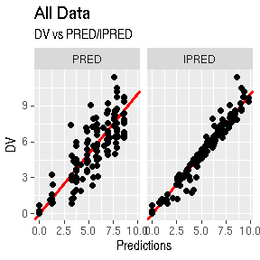

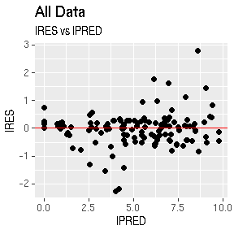

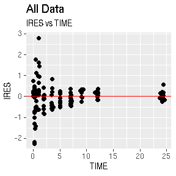

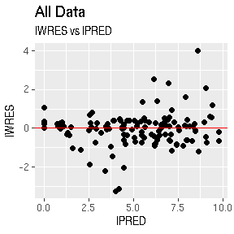

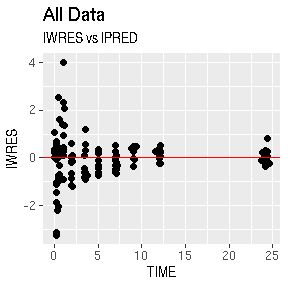

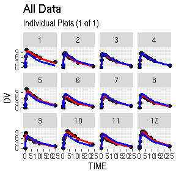

```r
plot(fit)
```

```r
print(fit)
```

```
#> ── nlmixr nlme by maximum likelihood (Solved; μ-ref & covs) nlme OBF fit ──
#>          OBJF      AIC      BIC Log-likelihood Condition Number
#> nlme 116.8727 373.4725 393.6521      -179.7363         17.08747
#>
#> ── Time (sec; $time): ─────────────────────────────────────────────────────
#>          nlme    setup table    other
#> elapsed 2.043 3.996983 0.062 1.252017
#>
#> ── Population Parameters ($parFixed or $parFixedDf): ──────────────────────
#>        Parameter  Est.     SE %RSE Back-transformed(95%CI) BSV(CV%)
#> tka       Log Ka 0.447  0.192   43       1.56 (1.07, 2.28)     68.7
#> tcl       Log Cl  1.02 0.0847 8.31       2.77 (2.35, 3.27)     26.9
#> tv         log V  3.45 0.0464 1.35       31.5 (28.7, 34.5)     13.6
#> add.sd           0.697                               0.697
#>        Shrink(SD)%
#> tka        0.241%
#> tcl         3.78%
#> tv          10.0%
#> add.sd
#>
#>   Covariance Type ($covMethod): nlme
#>   No correlations in between subject variability (BSV) matrix
#>   Full BSV covariance ($omega) or correlation ($omegaR; diagonals=SDs)
#>   Distribution stats (mean/skewness/kurtosis/p-value) available in $shrink
#>
#> ── Fit Data (object is a modified tibble): ────────────────────────────────
#> # A tibble: 132 x 18
#>   ID     TIME    DV  EVID  PRED    RES IPRED   IRES  IWRES eta.ka eta.cl
#>   <fct> <dbl> <dbl> <int> <dbl>  <dbl> <dbl>  <dbl>  <dbl>  <dbl>  <dbl>
#> 1 1     0      0.74     0  0     0.74   0     0.74   1.06   0.101 -0.479
#> 2 1     0.25   2.84     0  3.25 -0.410  3.84 -1.00  -1.44   0.101 -0.479
#> 3 1     0.570  6.57     0  5.83  0.744  6.78 -0.212 -0.305  0.101 -0.479
#> # … with 129 more rows, and 7 more variables: eta.v <dbl>, rx1c <dbl>,
#> #   ka <dbl>, cl <dbl>, v <dbl>, depot <dbl>, central <dbl>
```

```r
fit$eta
```

| ID | eta.ka | eta.cl | eta.v |
| --- | --- | --- | --- |
| 1 | 0.101 | -0.479 | -0.0819 |
| 2 | 0.21 | 0.141 | 0.0125 |
| 3 | 0.381 | 0.0252 | 0.0599 |
| 4 | -0.269 | -0.0219 | -0.00539 |
| 5 | -0.0269 | -0.156 | -0.134 |
| 6 | -0.384 | 0.374 | 0.194 |
| 7 | -0.763 | 0.145 | 0.0595 |
| 8 | -0.159 | 0.163 | 0.0985 |
| 9 | 1.37 | 0.042 | 0.00775 |
| 10 | -0.715 | -0.388 | -0.162 |
| 11 | 0.759 | 0.286 | 0.142 |
| 12 | -0.502 | -0.131 | -0.191 |

Default trace plots can be generated using:

```r
traceplot(fit)
```

but with a little more work, we can get a nicer set of iteration trace plots (“wriggly worms”)…

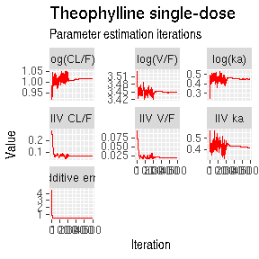

```r
iter <- fit2$par.hist.stacked
iter$Parameter[iter$par=="add.sd"] <- "Additive error"
iter$Parameter[iter$par=="eta.cl"]  <- "IIV CL/F"
iter$Parameter[iter$par=="eta.v"]   <- "IIV V/F"
iter$Parameter[iter$par=="eta.ka"]  <- "IIV ka"
iter$Parameter[iter$par=="tcl"]     <- "log(CL/F)"
iter$Parameter[iter$par=="tv"]      <- "log(V/F)"
iter$Parameter[iter$par=="tka"]     <- "log(ka)"
iter$Parameter <- ordered(iter$Parameter, c("log(CL/F)", "log(V/F)", "log(ka)",
                                            "IIV CL/F", "IIV V/F", "IIV ka",
                                            "Additive error"))

ggplot(iter, aes(iter, val)) +
  geom_line(col="red") +
  scale_x_continuous("Iteration") +
  scale_y_continuous("Value") +
  facet_wrap(~ Parameter, scales="free_y") +
  labs(title="Theophylline single-dose", subtitle="Parameter estimation iterations")
```

… and some random-effects histograms…

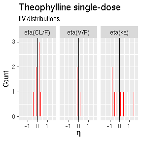

```r
etas <- data.frame(eta = c(fit2$eta$eta.ka, fit2$eta$eta.cl, fit2$eta$eta.v),
                   lab = rep(c("eta(ka)", "eta(CL/F)", "eta(V/F)"), each=nrow(fit2$eta)))
etas$lab <- ordered(etas$lab, c("eta(CL/F)","eta(V/F)","eta(ka)"))

ggplot(etas, aes(eta)) +
  geom_histogram(fill="red", col="white") +
  geom_vline(xintercept=0) +
  scale_x_continuous(expression(paste(eta))) +
  scale_y_continuous("Count") +
  facet_grid(~ lab) +
  coord_cartesian(xlim=c(-1.75,1.75)) +
  labs(title="Theophylline single-dose", subtitle="IIV distributions")
```

## xpose

This is all very nice. But what we really want is a complete suite of model diagnostic tools, like those available in xpose, right?

Restart R, and install xpose from CRAN, if you haven’t already…

```r
## install.packages("xpose")
library(xpose)
```

Now install the extension for nlmixr:

```
 devtools::install_github("nlmixrdevelopment/xpose.nlmixr")
```

… and convert your nlmixr fit object into an xpose fit object.

```
library(xpose.nlmixr)
xp <- xpose_data_nlmixr(fit2);
save(xp, file=xpdbLoc)
```

```r
xpdbLoc <- file.path(system.file(package="nlmixr"), "xpdb.rds");
if (file.exists(xpdbLoc)){
    load(xpdbLoc);
} else {
    stop("Need to generate nlmixr.xpose example")
}
```

```r
dv_vs_pred(xp)
```

```
#> Using data from $prob no.1
#> Filtering data by EVID == 0
#> Warning in grid.Call.graphics(C_lines, x$x, x$y, index, x$arrow): semi-
#> transparency is not supported on this device: reported only once per page
```

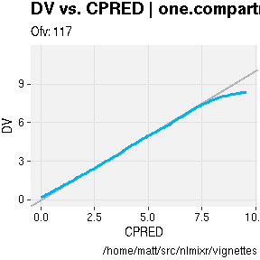

```r
dv_vs_ipred(xp)
```

```
#> Using data from $prob no.1
#> Filtering data by EVID == 0
#> Warning in grid.Call.graphics(C_lines, x$x, x$y, index, x$arrow): semi-
#> transparency is not supported on this device: reported only once per page
```

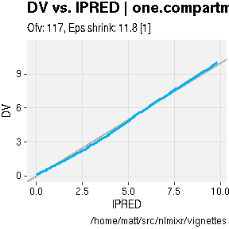

```r
dv_vs_pred(xp)
```

```
#> Using data from $prob no.1
#> Filtering data by EVID == 0
#> Warning in grid.Call.graphics(C_lines, x$x, x$y, index, x$arrow): semi-
#> transparency is not supported on this device: reported only once per page
```

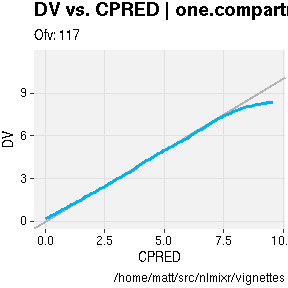

```r
absval_res_vs_pred(xp, res="IWRES")
```

```
#> Using data from $prob no.1
#> Filtering data by EVID == 0
#> Warning in grid.Call.graphics(C_lines, x$x, x$y, index, x$arrow): semi-
#> transparency is not supported on this device: reported only once per page
```

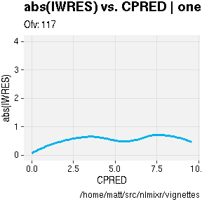

We can also replicate some of nlmixr’s internal plots…

```
#> Using data from $prob no.1
#> Filtering data by EVID == 0
#> Tidying data by ID, TIME, EVID, PRED, RES ... and 17 more variables
#> Warning in grid.Call.graphics(C_lines, x$x, x$y, index, x$arrow): semi-
#> transparency is not supported on this device: reported only once per page
```

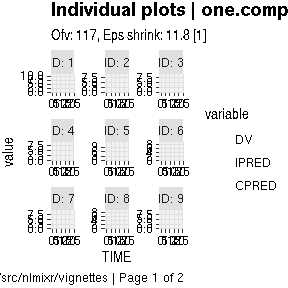

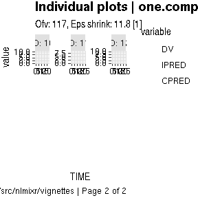

```r
ind_plots(xp, res="IWRES")
```

For more information about using xpose, see the Uppsala pharmacometrics group’s comprehensive site [here](https://uupharmacometrics.github.io/xpose/).

# The UI

The nlmixr modeling dialect, inspired by R and NONMEM, can be used to fit models using all current and future estimation alogorithms within nlmixr. Using these widely-used tools as inspiration has the advantage of delivering a model specification syntax taht is instantly familira to the majority of analysts working in pharmacometrics and related fields.

## Overall model structure

Model specifications for nlmixr are written using functions containing `ini` and `model` blocks. These functions can be called anything, but must contain these two components. Let’s look at a very simple one-compartment model with no covariates.

```r
f <- function() {
    ini({   # Initial conditions/variables
            # are specified here
    })
    model({ # The model is specified
            # here
    })
}
```

### The ini block

The `ini` block specifies initial conditions, including initial estimates and boundaries for those algorithms which support them (currently, the built-in `nlme` and `saem` methods do not). Nomenclature is similar to that used in NONMEM, Monolix and other similar packages. In the NONMEM world, the `ini` block is analogous to `$THETA`, `$OMEGA` and `$SIGMA` blocks.

```r
f <- function(){ # Note that arguments to the function are currently
                 # ignored by nlmixr
    ini({
        # Initial conditions for population parameters (sometimes
        # called THETA parameters) are defined by either '<-' or '='
        lCl <- 1.6      # log Cl (L/hr)

        # Note that simple expressions that evaluate to a number are
        # OK for defining initial conditions (like in R)
        lVc = log(90)  # log V (L)

        ## Also, note that a comment on a parameter is captured as a parameter label
        lKa <- 1       # log Ka (1/hr)

        # Bounds may be specified by c(lower, est, upper), like NONMEM:
        # Residuals errors are assumed to be population parameters
        prop.err <- c(0, 0.2, 1)

        # IIV terms will be discussed in the next example
    })

    # The model block will be discussed later
    model({})
}
```

As shown in the above example:

- Simple parameter values are specified using an R-compatible assignment
- Boundaries my be specified by `c(lower, est, upper)`.
- Like NONMEM, `c(lower,est)` is equivalent to `c(lower,est,Inf)`
- Also like NONMEM, `c(est)` does not specify a lower bound, and is equivalent to specifying the parameter without using R’s `c()` function.

These parameters can be named using almost any R-compatible name. Please note that:

- Residual error estimates should be coded as population estimates (i.e. using `=` or `<-`, not `~`).
- Variable names that start with `_` are not supported. Note that R does not allow variable starting with `_` to be assigned without quoting them.
- Naming variables that start with `rx_` or `nlmixr_` is not allowed, since RxODE and nlmixr use these prefixes internally for certain estimation routines and for calculating residuals.
- Variable names are case-sensitive, just like they are in R. `CL` is not the same as `Cl`.

In mixture models, multivariate normal individual deviations from the normal population and parameters are estimated (in NONMEM these are called “ETA” parameters). Additionally, the variance/covariance matrix of these deviations are is also estimated (in NONMEM this is the “OMEGA” matrix). These also take initial estimates. In nlmixr, these are specified by the `~` operator. This that is typically used in statistics R for “modeled by”, and was chosen to distinguish these estimates from the population and residual error parameters.

Continuing from the prior example, we can annotate the estimates for the between-subject error distribution…

```r
f <- function(){
    ini({
        lCl <- 1.6      # log Cl (L/hr)
        lVc = log(90)   # log V (L)
        lKa <- 1        # log Ka (1/hr)
        prop.err <- c(0, 0.2, 1)

        # Initial estimate for ka IIV variance
        # Labels work for single parameters
        eta.ka ~ 0.1    ## BSV Ka

        # For correlated parameters, you specify the names of each
        # correlated parameter separated by a addition operator `+`
        # and the left handed side specifies the lower triangular
        # matrix initial of the covariance matrix.
        eta.cl + eta.vc ~ c(0.1,
                            0.005, 0.1)

        # Note that labels do not currently work for correlated
        # parameters.  Also, do not put comments inside the lower
        # triangular matrix as this will currently break the model.
    })

    # The model block will be discussed later
    model({})
}
```

As shown in the above example:

Currently, comments inside the lower triangular matrix are not allowed.

### The model block

The `model` block specifies the model, and is analogous to the `$PK`, `$PRED` and `$ERROR` blocks in NONMEM.

Once the initialization block has been defined, you can define a model in terms of the variables defined in the `ini` block. You can also mix RxODE blocks into the model if needed.

The current method of defining a nlmixr model is to specify the parameters, and then any required RxODE lines. Continuing the annotated example:

```r
f <- function(){
    ini({
        lCl <- 1.6       # log Cl (L/hr)
        lVc <- log(90)   # log Vc (L)
        lKA <- 0.1       # log Ka (1/hr)
        prop.err <- c(0, 0.2, 1)

        eta.Cl ~ 0.1     # BSV Cl
        eta.Vc ~ 0.1     # BSV Vc
        eta.KA ~ 0.1     # BSV Ka
    })
    model({
        # Parameters are defined in terms of the previously-defined
        # parameter names:
        Cl <- exp(lCl + eta.Cl)
        Vc =  exp(lVc + eta.Vc)
        KA <- exp(lKA + eta.KA)

        # Next, the differential equations are defined:
        kel <- Cl / Vc;

        d/dt(depot)  = -KA*depot;
        d/dt(centr)  =  KA*depot-kel*centr;

        # And the concentration is then calculated
        cp = centr / Vc;
        # Finally, we specify that the plasma concentration follows
        # a proportional error distribution (estimated by the parameter
        # prop.err)
        cp ~ prop(prop.err)
    })

}
```

A few points to note:

- Parameters are defined before the differential equations. Currently directly defining the differential equations in terms of the population parameters is not supported.
- The differential equations, parameters and error terms are in a single block, instead of multiple sections.
- Additionally state names, calculated variables, also cannot start with either `rx_` or `nlmixr_` since these are used internally in some estimation routines.
- Errors are specified using the tilde, `~`. Currently you can use either `add(parameter)` for additive error, `prop(parameter)` for proportional error or `add(parameter1) + prop(parameter2)` for combined additive and proportional error. You can also specify `norm(parameter)` for additive error, since it follows a normal distribution.
- Some routines, like `saem`, require parameters expressed in terms of `Pop.Parameter + Individual.Deviation.Parameter + Covariate*Covariate.Parameter`. The order of these parameters does not matter. This is similar to NONMEM’s mu-referencing, though not as restrictive. This means that for `saem`, a parameterization of the form `Cl <- Cl*exp(eta.Cl)` is not allowed.
- The type of parameter in the model is determined by the `ini` block; covariates used in the model are not included in the `ini` block. These variables need to be present in the modeling dataset for the model to run.

## Running models

Models can be fitted several ways, including via the [magrittr] forward-pipe operator.

```
fit <- nlmixr(one.compartment) %>% saem.fit(data=theo_sd)
```

```
fit2 <- nlmixr(one.compartment, data=theo_sd, est="saem")
```

```
fit3 <- one.compartment %>% saem.fit(data=theo_sd)
```

Options to the estimation routines can be specified using nlmeControl for nlme estimation:

```
fit4 <- nlmixr(one.compartment, theo_sd,est="nlme",control = nlmeControl(pnlsTol = .5))
```

where options are specified in the `nlme` documentation. Options for saem can be specified using `saemControl`:

```
fit5 <- nlmixr(one.compartment,theo_sd,est="saem",control=saemControl(n.burn=250,n.em=350,print=50))
```

this example specifies 250 burn-in iterations, 350 em iterations and a print progress every 50 runs.

## Model Syntax for solved PK systems

Solved PK systems are also currently supported by nlmixr with the ‘linCmt()’ pseudo-function. An annotated example of a solved system is below:

```r
f <- function(){
    ini({
        lCl <- 1.6      #log Cl (L/hr)
        lVc <- log(90)  #log Vc (L)
        lKA <- 0.1      #log Ka (1/hr)
        prop.err <- c(0, 0.2, 1)
        eta.Cl ~ 0.1   # BSV Cl
        eta.Vc ~ 0.1   # BSV Vc
        eta.KA ~ 0.1   # BSV Ka
    })
    model({
        Cl <- exp(lCl + eta.Cl)
        Vc = exp(lVc + eta.Vc)
        KA <- exp(lKA + eta.KA)
        ## Instead of specifying the ODEs, you can use
        ## the linCmt() function to use the solved system.
        ##
        ## This function determines the type of PK solved system
        ## to use by the parameters that are defined.  In this case
        ## it knows that this is a one-compartment model with first-order
        ## absorption.
        linCmt() ~ prop(prop.err)
    })
}
```

A few things to keep in mind: * Currently the solved systems support either oral dosing, IV dosing or IV infusion dosing and does not allow mixing the dosing types. * While RxODE allows mixing of solved systems and ODEs, this has not been implemented in nlmixr yet. * The solved systems implemented are the one, two and three compartment models with or without first-order absorption. Each of the models support a lag time with a tlag parameter. * In general the linear compartment model figures out the model by the parameter names. nlmixr currently knows about numbered volumes, `Vc`/`Vp`, Clearances in terms of both `Cl` and `Q`/`CLD`. Additionally nlmixr knows about elimination micro-constants (ie `K12`). Mixing of these parameters for these models is currently not supported.

## Checking model syntax

After specifying the model syntax you can check that nlmixr is interpreting it correctly by using the nlmixr function on it. Using the above function we can get:

```r
nlmixr(f)
```

```
#> ▂▂ RxODE-based 1-compartment model with first-order absorption ▂▂▂▂▂▂▂▂▂▂▂▂
#> ── Initialization: ────────────────────────────────────────────────────────
#> Fixed Effects ($theta):
#>     lCl     lVc     lKA
#> 1.60000 4.49981 0.10000
#>
#> Omega ($omega):
#>        eta.Cl eta.Vc eta.KA
#> eta.Cl    0.1    0.0    0.0
#> eta.Vc    0.0    0.1    0.0
#> eta.KA    0.0    0.0    0.1
#> ── μ-referencing ($muRefTable): ───────────────────────────────────────────
#> ┌─────────┬─────────┐
#> │ theta   │ eta     │
#> ├─────────┼─────────┤
#> │ lCl     │ eta.Cl  │
#> ├─────────┼─────────┤
#> │ lVc     │ eta.Vc  │
#> ├─────────┼─────────┤
#> │ lKA     │ eta.KA  │
#> └─────────┴─────────┘
#> ── Model: ─────────────────────────────────────────────────────────────────
#>         Cl <- exp(lCl + eta.Cl)
#>         Vc = exp(lVc + eta.Vc)
#>         KA <- exp(lKA + eta.KA)
#>         ## Instead of specifying the ODEs, you can use
#>         ## the linCmt() function to use the solved system.
#>         ##
#>         ## This function determines the type of PK solved system
#>         ## to use by the parameters that are defined.  In this case
#>         ## it knows that this is a one-compartment model with first-order
#>         ## absorption.
#>         linCmt() ~ prop(prop.err)
#> ▂▂▂▂▂▂▂▂▂▂▂▂▂▂▂▂▂▂▂▂▂▂▂▂▂▂▂▂▂▂▂▂▂▂▂▂▂▂▂▂▂▂▂▂▂▂▂▂▂▂▂▂▂▂▂▂▂▂▂▂▂▂▂▂▂▂▂▂▂▂▂▂▂▂▂
```

In general this gives you information about the model (what type of solved system/RxODE), initial estimates as well as the code for the model block.